# ReadMe package for Content Analysis

28 Giugno 2018

## Introduction

### Content Analysis

What is **Sentiment Analysis**?

It is the process of *categorizing* opinions about a specific sentence or text.

**Classification methods**

*Goal:* increasing the accuracy of individual classifications, which is the highest number of correct predictions.

Suppose that missclassifications mostly occur in some specific categories. This is the case of a *statistical bias*: average difference between true and estimated proportion of documents in each category.

Here comes **Content Analysis**

*Goal*: getting approximately unbiased estimates of category proportions.

Notice that there exists *no necessary connection* between low misclassification rates and low bias in each category, except at the extremes of classification.

## Theoretical background

### Analyzing text statistically

Documents need to be **preprocessed** by converting in lowercase words, revoming punctuation, spaces, stop words, applying stemming and creating the so called "bag of words".

We will use the following *notation*.

- \(j=1,\dots,J\) are document categories;
- there are two sets of text documents:
  - labeled training set \(i=1,\dots,n\);
  - unlabeled test set \(l=1,\dots,L\);
- \(D_i = j\) if document \(i\) belongs to category \(j\);
- \(\{S_{i1},\dots,S_{iK}\}\) is the set of stem words for all documents, where \(S_{ik}=\delta_{ik}\).

## Theoretical background

### Analyzing text statistically

**Individual classifications**

\(\{D_1,\dots,D_L\}\)

vs

**Proportions of documents for each class**

\(P(D) = \{P(D=1),\dots,P(D=J)\}\)

where \(P(D=j) = \frac{1}{L} \sum_{l=1}^{L} I(D_l = j)\) is the proportion of documents belonging to category \(j\).

## Theoretical background

### The method

The method provided by `ReadMe` package allows to calculate these estimates **without performing an individual classification**, let's understand how.

Let \(\hat{D}\) be the estimated classification for the documents. Then the *law of total probability* allows to express the proportion of documents estimated to be in category \(j\) in terms of the **missclassification probabilities** \(P(\hat{D}=j \,|\, D=j')\) and the **true proportion** as \[ P(\hat{D}=j)=\sum_{j'=1}^{L} P(\hat{D}=j \,|\, D=j') P(D=j'). \]

The idea is to avoid computing \(P(\hat{D}=j)\), based on the fact that each text is written by a person with a specific *opinion*.

## Theoretical background

### The method

Since the words chosen are by definition a function of the document category and the categories partition our sample space, the probability of each of the \(2^k\) stem word combinations (*stem profiles*) occuring is \[ P(S=s)=\sum_{j=1}^{L} P(S=s \,|\, D=j) P(D=j) \] where \(P(S=s | D=j)\) is the probability of \(s\) occuring within a document of category \(j\).

We get the equivalent matrix expression  
\[ \underset{2^K\times1}{P(S)} = \underset{2^K\times J}{P(S\,|\,D)} \underset{J\times1}{P(D)}. \]

## Theoretical background

### The method

The **fundamental assumption** for this model is the proportion \(P(S=s \,|\, D=j)\) being the same for both training and test set, so it assumes that the documents in the labeled set contain a sufficient number of examples to describe the language used in each category.

We can now directly solve this equation using regression on the coefficients \(P(D)\), but there are two relevant problems we have to pay attention to:

- \(K\) can be very large, so \(2^K\) makes this model **computationally expensive**;
- The matrix \(P(S=s \,|\, D=j)\) is **sparse**, since \(n\) is usually much smaller than \(2^K\).

How do we avoid these problems?

We randomly choose a subset of words, as seen in [2].

## Inside ReadMe package

### functions

The package contains three main functions:

- `undergrad()` translates a set of texts stored in a single folder into a dataset, where each text is a row and each word is a column, the so called "**document term matrix**", based on a specific threshold;
- `preprocess()` removes all columns with null variance, i.e. extremely **rare words**;
- `readme()` computes the **real proportions** on the train set and the **estimated proportions** on the test set. It optionally computes **bootstrap intervals** too.

Let's take a better look into these function through an example.

## Inside ReadMe package

### Rotten Tomatoes dataset

The first dataset we analyzed contains \(8529\) movie reviews from the famous website *www.rottentomatoes.com*, labeled with ratings from \(1\) to \(5\).

The inputs for `undergrad()` are the text files containing all the reviews and a data frame containing file names, classification labels, and a (randomly generated) binary value separating train set from test set.

```
## # A tibble: 6 x 3
##   filename truth trainingset
##   <chr>    <int>       <int>
## 1 1.txt        1           0
## 2 2.txt        4           1
## 3 3.txt        1           0
## 4 4.txt        3           1
## 5 5.txt        1           1
## 6 6.txt        4           0
```

`preprocess()` found no invariant columns, probably due to the large dimension of our dataset.

## Inside ReadMe package

### Rotten Tomatoes dataset

After applying the main function `readme()`, we computed the same proportions from the results of two diffent classification methods: support vector machines using **linear** and **radial** kernels respectively.

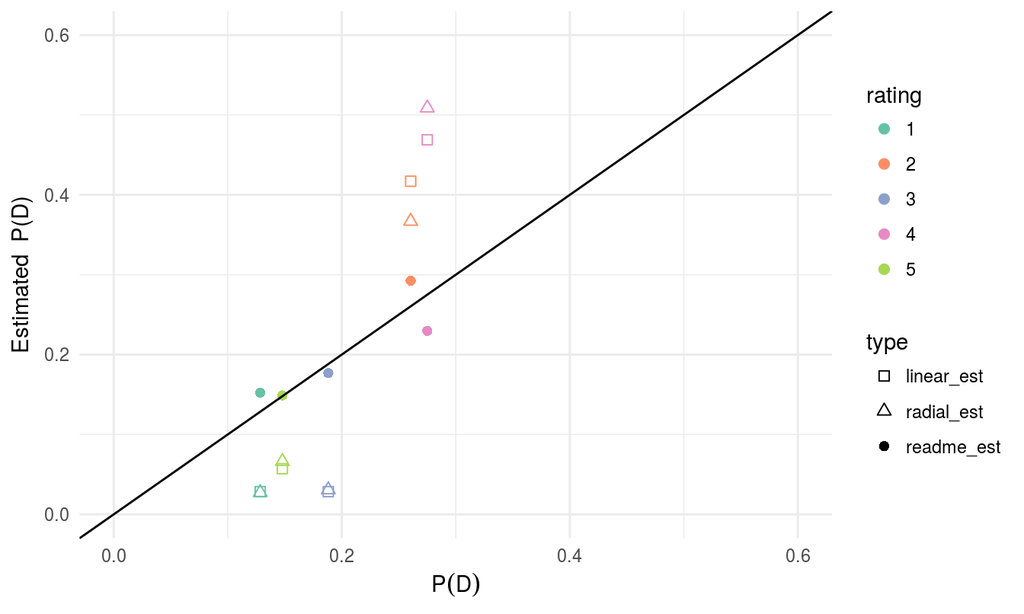

## Inside ReadMe package

### Rotten Tomatoes dataset

The following tables compares the **mean absolute errors** on the proportions for these methods.

```
##                        linear    radial     readme
## mean_absolute_error 0.1388042 0.1347011 0.02268683
```

## Testing Readme package

### Amazon reviews dataset

Let's now take a look at some real examples of categorical proportions.

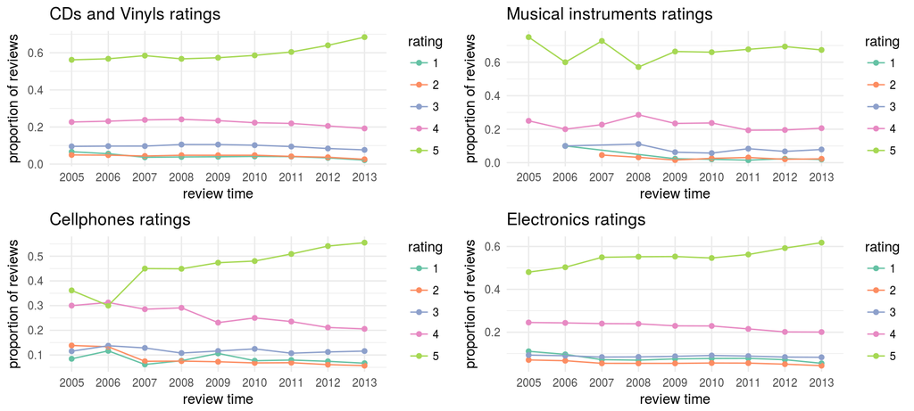

## Testing Readme package

### An overview

Tested on **Amazon CD and vinyls** dataset

**The dataset**

- Provided by University of California, San Diego
- \(1097592\) reviews
- five different labels
- Timespan of various years

Performed **tests**

- Influence of dimension of the training set
- Influence of words number in document
- Assessing optimal parameters

## Main characteristics of the dataset

### Words and ratings distributions

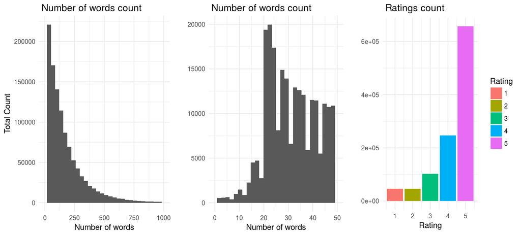

## Relationship between number of words and ratings

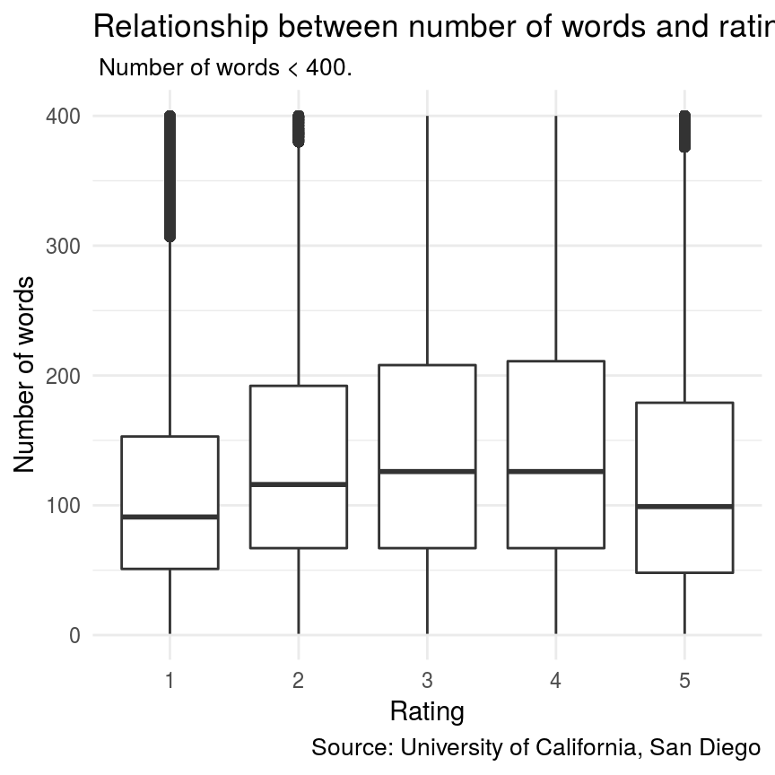

- There is no significant relationship between the number of words in the text and the final rating;
- It's possible to use this dataset to study the *influence of the number of words* on it's performace.

## Testing Readme package

### Influence of dimension of the training set

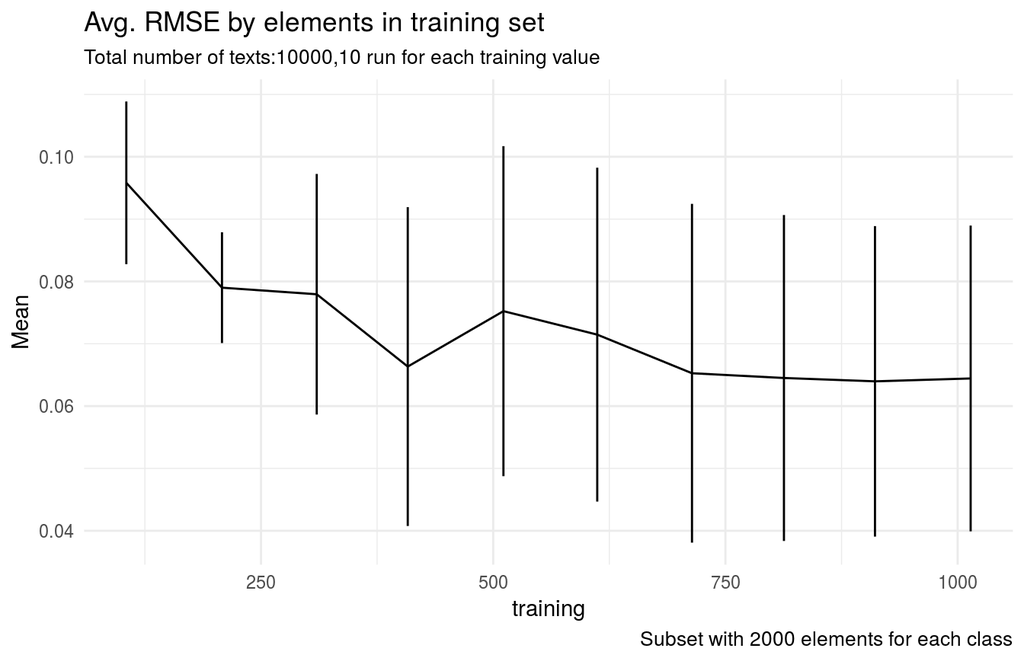

## Testing readme package

### Influence of number of words per document

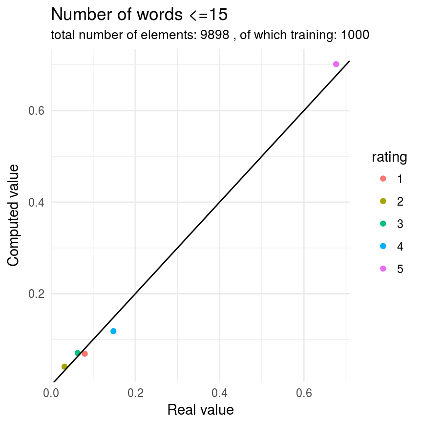

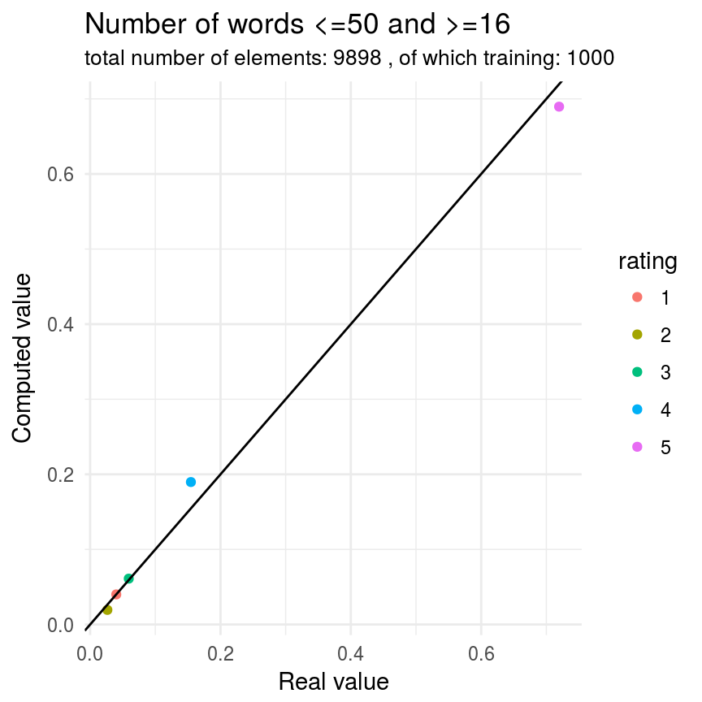

## Testing readme package

### Influence of number of words per document

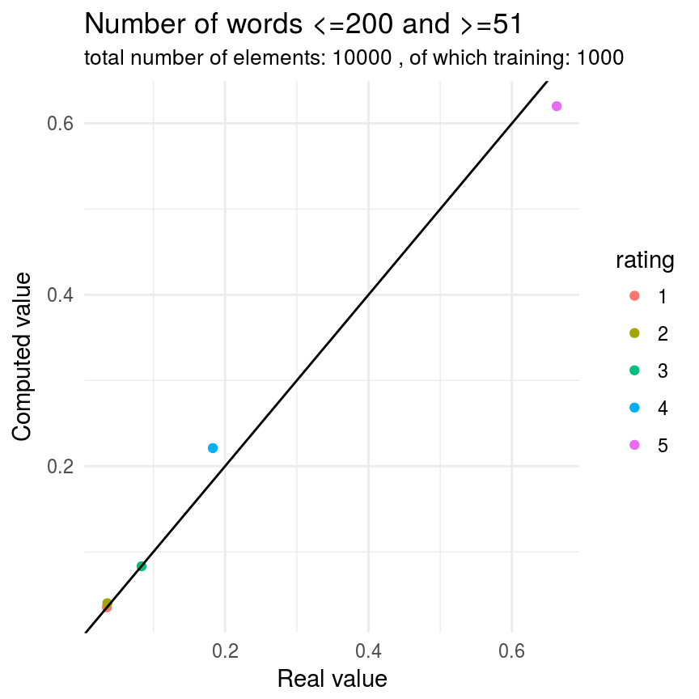

- The *accuracy* doesn't seem to be affected by a small number of words in the single document;
- That's a great news since it means that this package can be used to *analyze Tweets*, where a major challenge is posed by the fact that users are limited to 240 characters;
- So let's see a real case application of the package .

## Using ReadMe on Italian Tweets

An overview of the italian institutional crisis on the 27th of May.

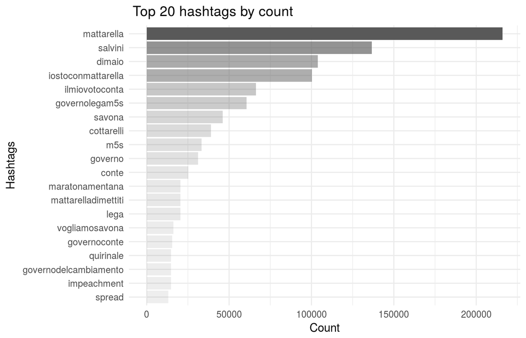

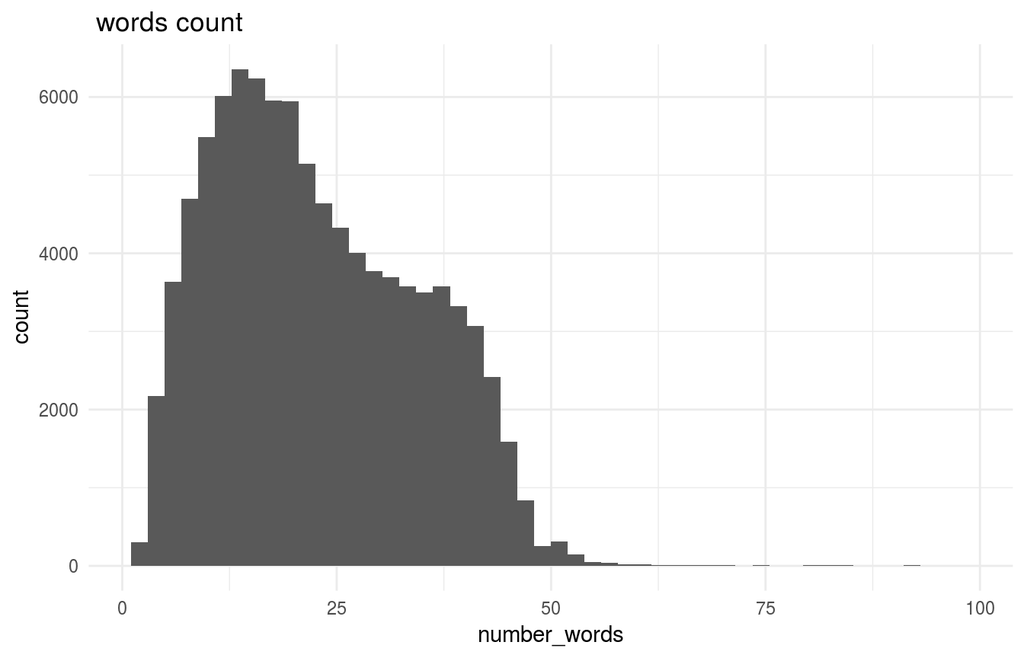

## Twitter activity

### Signs of polarization given by some explicit hashtags

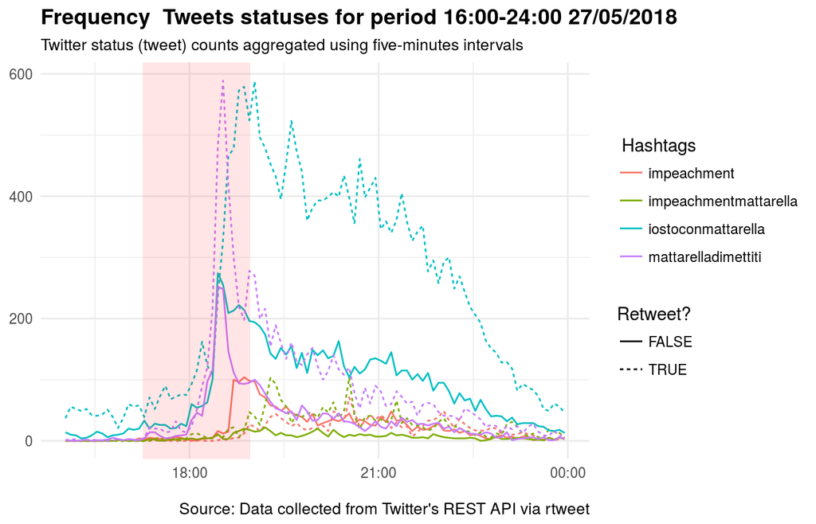

## Major challenge

### Build the labelled trainingset

Proposed solution

- *First*: Gather tweets with hashtags with explicit meaning.

**#iostoconmattarella**

VS

**#mattarelladimettiti, #Impeachment, #Impeachmentmattarella**

- *Second*: Select those users that never used both of them, and retain only tweets written from them.

## Testing Readme on Italian tweets dataset

### Language indipendent since we dropped stemming

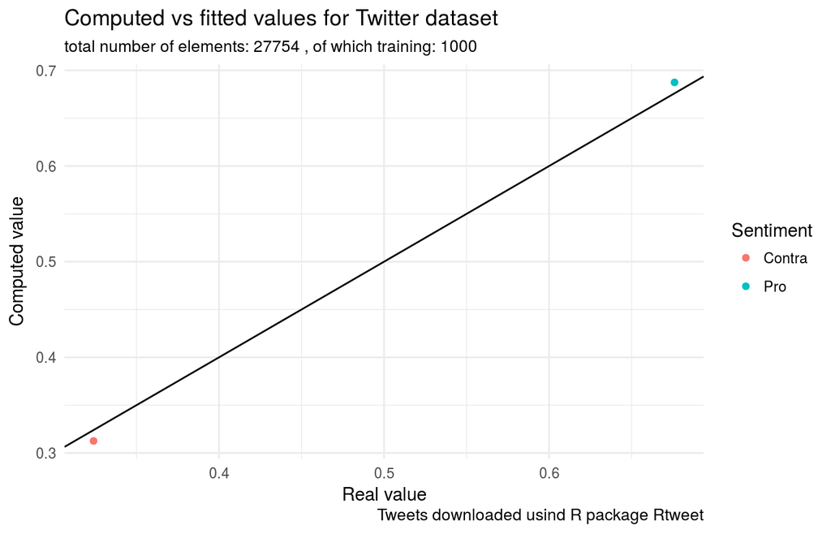

## Sentiment towards President Mattarella

### Estimated from 10000 random sampled tweets with #Mattarella

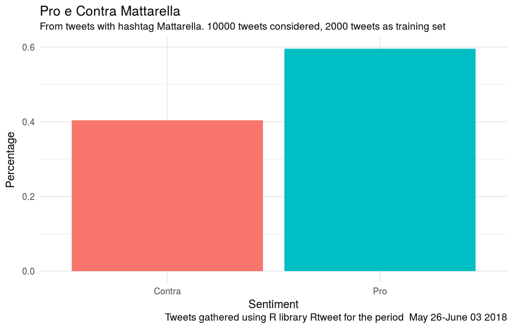

## Bibliography

[1] "A Method of Automated Nonparametric Content Analysis for Social Science", D. J. Hopkins, G. King, 2010.

[2] "Verbal Autopsy Methods with Multiple Causes of Death", King, Gary and Ying Lu, 2008.

[3] "ReadMe: Software for Automated Content Analysis", D. Hopkins, G. King, M. Knowles, S. Melendez, 2012.

[4] Amazon dataset: http://jmcauley.ucsd.edu/data/amazon/

[5] ReadMe software releases: https://gking.harvard.edu/readme

## Thank you for your attention